# A Guide to Graduate School Admissions

Maya Chudamani, Sahana Raju, Akhil Saini

# 1 Background and Setting Up

## 1.1 Background

Our data sets both center around graduate programs in order to provide students who are looking to join graduate programs more information regarding admission qualifications as well as to bolster their knowledge on good graduate schools throughout the country.

Graduate School is a goal for many students in University. However, unlike in high school, the resources and information are not as widespread, so prospective young adults have to independently do research to be informed. There are many factors in the application process, and the purpose of this project is to help gain a better understanding on what is needed for a successful higher education.

Data Science provides a manner with which we are able to best figure out what aspects of the application process are the most important. While merely looking at a table can give us a general idea, various tests and visualization can help us conclude what makes an ideal applicant. With this information, we, along with other undergraduate students, can be best prepared.

Although we will do our best to prepare our audience using data obtained from two different sources to guide them in the right direct of the daunting application process, we would also like to include this link to our audience - https://getunbound.org/blog/getting-into-grad-school

In it, the author explains the different aspect of the admissions and backs up a lot of the information we will be showing in numbers.

## 1.2 Setting up

Prior to accessing our dataset, we need to first load the packages necessary for this study.

```r
knitr::opts_chunk$set(echo = TRUE)
library(tidyverse)
library(lubridate)
library(broom)
library(caret)
library(plotROC)
library(magrittr)
library(dplyr)
library(ggplot2)
library(ggrepel)
library(ggmap)
library(tmap)
library(tmaptools)
library(leaflet)
library(stringr)
library(pracma)
library(rvest)
```

# 2 Parsing

## 2.1 Scraping

```r
url <- "https://thebestschools.org/rankings/20-top-graduate-programs-computer-science-application-process/"


dl_tab <- url %>%
  read_html() %>%
  html_text() %>%
  str_split("\n")

  dl_tab <- dl_tab[[1]][373:622]

  #dl_tab
  df <- dplyr::as_data_frame(dl_tab)

  df
```

```
## # A tibble: 250 x 1
##    value
##    <chr>
##  1 1. Stanford University
##  2 ""
##  3 Stanford, California
##  4 ""
##  5 Interested in robotics or A.I.? Stanford has received plenty of recogni…
##  6 ""
##  7 Founded in 1965, the Stanford Computer Science (CS) Department program …
##  8 ""
##  9 Donald Knuth, a notable Computer Science alumnus and a Stanford profess…
## 10 ""
## # … with 240 more rows
```

```r
  #Scraping all of the data and putting them into separate schools

  #Scraping Data for Stanford
  temp <- c(df[1,],df[3,])
  names(temp) <- c("University", "Location")
  df_stan <- as_data_frame(temp)
  df_stan <- separate(df_stan,University,c("rank","College"), sep = "[.]")

  df_final <- df_stan

  #Scraping Data for MIT
  temp <- c(df[11,],df[13,])
  names(temp) <- c("University", "Location")
  df_mit <- as_data_frame(temp)
  df_mit <- separate(df_mit,University,c("rank","College"), sep = "[.]")
  df_final <- bind_rows(df_final)

  #Scraping Data for Berkley
  temp <- c(df[25,],df[27,])
  names(temp) <- c("University", "Location")
  df_berk  <- as_data_frame(temp)
  df_berk  <- separate(df_berk ,University,c("rank","College"), sep = "[.]")

  #Scraping Data for Purdue
  temp <- c(df[37,],df[39,])
  names(temp) <- c("University", "Location")
  df_pr  <- as_data_frame(temp)
  df_pr  <- separate(df_pr ,University,c("rank","College"), sep = "[.]")

  #Scraping Data for CMU
  temp <- c("5. Carnegie Mellon (Pittsburgh)",df[54,])
  names(temp) <- c("University", "Location")
  df_cmu  <- as_data_frame(temp)
  df_cmu  <- separate(df_cmu ,University,c("rank","College"), sep = "[.]")


  #Scraping Data for Cornell
  temp <- c(df[63,],df[65,])
  names(temp) <- c("University", "Location")
  df_corn  <- as_data_frame(temp)
  df_corn  <- separate(df_corn ,University,c("rank","College"), sep = "[.]")


   #Scraping Data for USC
  temp <- c(df[73,],df[76,])
  names(temp) <- c("University", "Location")
  df_usc  <- as_data_frame(temp)
  df_usc  <- separate(df_usc ,University,c("rank","College"), sep = "[.]")

  #Scraping Data for UTA
  temp <- c(df[86,],df[88,])
  names(temp) <- c("University", "Location")
  df_uta  <- as_data_frame(temp)
  df_uta  <- separate(df_uta ,University,c("rank","College"), sep = "[.]")

  #Scraping Data for Harvard
  temp <- c(df[98,],df[100,])
  names(temp) <- c("University", "Location")
  df_harv  <- as_data_frame(temp)
  df_harv <- separate(df_harv ,University,c("rank","College"), sep = "[.]")

  #Scraping Data for CalTech
  temp <- c(df[110,],df[112,])
  names(temp) <- c("University", "Location")
  df_calt  <- as_data_frame(temp)
  df_calt <- separate(df_calt ,University,c("rank","College"), sep = "[.]")

 #Scraping Data for University of Chicago
  temp <- c(df[123,],df[125,])
  names(temp) <- c("University", "Location")
  df_uchic  <- as_data_frame(temp)
  df_uchic <- separate(df_uchic,University,c("rank","College"), sep = "[.]")

  #Scraping Data for UMD
  temp <- c(df[137,],df[139,])
  names(temp) <- c("University", "Location")
  df_umd   <- as_data_frame(temp)
  df_umd  <- separate(df_umd ,University,c("rank","College"), sep = "[.]")

  #Scraping Data for Unviersity of Carolina SD
  temp <- c(df[149,],df[151,])
  names(temp) <- c("University", "Location")
  df_ucsd   <- as_data_frame(temp)
  df_ucsd  <- separate(df_ucsd ,University,c("rank","College"), sep = "[.]")

  df_uma <- df[160:172,]
  #Scraping Data for University of Michigan Ann Arbor
  temp <- c(df[161,],df[163,])
  names(temp) <- c("University", "Location")
  df_uma   <- as_data_frame(temp)
  df_uma  <- separate(df_uma ,University,c("rank","College"), sep = "[.]")

  #Scraping Data for Purdue
  temp <- c(df[173,],df[176,])
  names(temp) <- c("University", "Location")
  df_purd   <- as_data_frame(temp)
  df_purd  <- separate(df_purd ,University,c("rank","College"), sep = "[.]")

  #Scraping Data for U Columbia
  temp <- c(df[186,],df[188,])
  names(temp) <- c("University", "Location")
  df_columb   <- as_data_frame(temp)
  df_columb  <- separate(df_columb ,University,c("rank","College"), sep = "[.]")

  #Scraping Data for FOU
  temp <- c(df[200,],df[202,])
  names(temp) <- c("University", "Location")
  df_fou   <- as_data_frame(temp)
  df_fou  <- separate(df_fou ,University,c("rank","College"), sep = "[.]")

  #Scraping Data for Georgia Tech
  temp <- c(df[214,],df[216,])
  names(temp) <- c("University", "Location")
  df_gtech   <- as_data_frame(temp)
  df_gtech  <- separate(df_gtech ,University,c("rank","College"), sep = "[.]")

  #Scraping Data for UCLA
  temp <- c("19. University of California Los Angeles",df[228,])
  names(temp) <- c("University", "Location")
  df_ucla  <- as_data_frame(temp)
  df_ucla <- separate(df_ucla ,University,c("rank","College"), sep = "[.]")

  #Scraping Data for Yale
  temp <- c(df[238,],df[240,])
  names(temp) <- c("University", "Location")
  df_yale   <- as_data_frame(temp)
  df_yale  <- separate(df_yale ,University,c("rank","College"), sep = "[.]")

 df_final <- bind_rows(df_stan,df_mit,df_pr,df_berk,df_cmu,df_corn,df_usc,df_uta,df_harv,df_calt,df_uchic,df_umd,df_ucsd,df_uma,df_purd,df_columb,df_fou,
                        df_gtech,df_ucla,df_yale)

 df_final <- df_final %>%
   mutate(lat = geocode_OSM(College, as.data.frame = TRUE)[[2]],lng = geocode_OSM(College, as.data.frame = TRUE)[[3]] )

 df_final
```

```
## # A tibble: 20 x 5
##    rank  College                           Location              lat    lng
##    <chr> <chr>                             <chr>               <dbl>  <dbl>
##  1 1     " Stanford University"            Stanford, Californ…  37.4 -122.
##  2 2     " Massachusetts Institute of Tec… Cambridge, Massach…  42.4  -71.1
##  3 4     " Princeton University"           Princeton, New Jer…  40.3  -74.7
##  4 3     " University of California Berke… Berkeley, Californ…  37.9 -122.
##  5 5     " Carnegie Mellon (Pittsburgh)"   Pittsburgh, Pennsy…  40.4  -79.9
##  6 6     " Cornell University"             Ithica, New York     42.5  -76.5
##  7 7     "  University of Southern Califo… Los Angeles, Calif…  34.0 -118.
##  8 8     " The University of Texas at Aus… Austin, Texas        30.3  -97.7
##  9 9     " Harvard University"             Cambridge, Massach…  42.4  -71.1
## 10 10    " California Institute of Techno… Pasadena, Californ…  34.1 -118.
## 11 11    " University of Illinois at Urba… Champaign County, …  40.1  -88.2
## 12 12    " University of Maryland College… College Park, Mary…  39.0  -76.9
## 13 13    " University of California San D… San Diego, Califor…  32.9 -117.
## 14 14    " University of Michigan Ann Arb… Ann Arbor, Michigan  42.3  -83.7
## 15 15    " Purdue University"              West Lafayette, In…  40.4  -86.9
## 16 16    " Columbia University"            New York City, New…  40.8  -74.0
## 17 17    " University of Washington"       Seattle, Washington  47.7 -122.
## 18 18    " Georgia Institute of Technolog… Atlanta, Georgia     33.8  -84.4
## 19 19    " University of California Los A… Los Angeles, Calif…  34.1 -118.
## 20 20    " Yale University"                New Haven, Connect…  41.3  -73.0
```

```r
  #as_data_frame(dl_tab)
```

## 2.2 Map of the Previous Data Frame

We know that a lot of people who are pursuing graduate programs may already have a life style - they may be married, already have a job, or may need to stay close to certain priorities near where they live. We thought it would be helpful to visualize the locations of the top 20 graduate programs in order for people to be able to see the closest ones that they live next to. Since each field of study has its own “top 20 schools” we picked computer science to showcase as an example. We gathered the data from https://thebestschools.org/rankings/20-top-graduate-programs-computer-science-application-process/ (as done in the previous dataset as well)

This map is extremely useful in being able to visualize the data that we have created and to show the locations of the top 20 graduate programs in the USA. As you scroll in , the colleges are identified by the emojis of universities. We used the leaflet library in order to create this map.

More information on how to create maps in R, take a look at https://rstudio.github.io/leaflet/markers.html. This website will give an in dept explanation on how to create a map and integrate markers that pin point certain locations. Additioanlly, we were able to find the geolocation(longitude and latitude) of a given college through the use of geocode_OSM. To learn more about this function, take a look at this - https://www.rdocumentation.org/packages/tmap/versions/1.6-1/topics/geocode_OSM .

```r
schoolIcons <- icons(
  iconUrl = "https://emojipedia-us.s3.dualstack.us-west-1.amazonaws.com/thumbs/240/google/146/school_1f3eb.png",
  iconWidth = 22, iconHeight = 22
)
grad_map <- leaflet(df_final) %>%
  addTiles() %>%
  setView(lat=37.9, lng=-96, zoom=4) %>%
  addMarkers(~lng,~lat,label=~College,icon = schoolIcons, clusterOptions = markerClusterOptions(), popup=paste("College:", df_final$College, "<br>",
                                                                                            "Location:",df_final$Location))
grad_map
```

[interactive chart not shown]

# 3 Data Curation

For the rest of our project, the dataset we will be using comes from a comma-separated values (CSV) file, found on https://www.kaggle.com/mohansacharya/graduate-admissions/downloads/graduate-admissions.zip/2. This data will allow us to do analysis on the factors that people need to consider when applying to graduate school. We will delve into the details of the factors of graduate school admission that this dataset focuses later.

We can view the data by calling the read_csv command on the downloaded file.

```r
csv <- "./Admission_Predict.csv"
df <- read_csv(csv)
df
```

```
## # A tibble: 400 x 9
##    `Serial No.` `GRE Score` `TOEFL Score` `University Rat…   SOP   LOR
##           <dbl>       <dbl>         <dbl>            <dbl> <dbl> <dbl>
##  1            1         337           118                4   4.5   4.5
##  2            2         324           107                4   4     4.5
##  3            3         316           104                3   3     3.5
##  4            4         322           110                3   3.5   2.5
##  5            5         314           103                2   2     3
##  6            6         330           115                5   4.5   3
##  7            7         321           109                3   3     4
##  8            8         308           101                2   3     4
##  9            9         302           102                1   2     1.5
## 10           10         323           108                3   3.5   3
## # … with 390 more rows, and 3 more variables: CGPA <dbl>, Research <dbl>,
## #   `Chance of Admit` <dbl>
```

# 4 Management

Now that we have the data, we should understand what the components are.

## 4.1 Missing Values

First things first, we need to check and make sure there are no missing values in the dataset. We can use the apply function, which takes a variable, margin, and function. The variable in this case would be the function is.na applied on the dataset, df. This creates a matrix filled with boolean values for each value in the dataset, whether it is marked “NA” or not. We use a margin of 2 so the function is applied by column, and the function sum adds up the number of NA values in each column.

```r
apply(is.na(df),2, sum)
```

```
##        Serial No.         GRE Score       TOEFL Score University Rating
##                 0                 0                 0                 0
##               SOP               LOR              CGPA          Research
##                 0                 0                 0                 0
##   Chance of Admit
##                 0
```

We find that our dataset has no missing values and can proceed.

## 4.2 Entries

The entries for this dataframe are individuals who have applied to graduate school. Each entry, or row, corresponds to one person.

## 4.3 Attributes

There are several types of attributes in R, as each column is made up of values of a particular class. Some of the common data types can be found at https://swcarpentry.github.io/r-novice-inflammation/13-supp-data-structures/

The attributes (or columns) in the dataset are as follows: Serial No., GRE Score, TOEFL Score, University Rating, SOP, LOR, GPA, Research, and Chance of Admit

### 4.3.1 Serial Number

The serial number of each entry merely identifies the row the entry is in. As a result, it does not need to be kept in the dataframe.

```r
# remove first column containing Serial Number
tidy_data <- df[,-1]
tidy_data
```

```
## # A tibble: 400 x 8
##    `GRE Score` `TOEFL Score` `University Rat…   SOP   LOR  CGPA Research
##          <dbl>         <dbl>            <dbl> <dbl> <dbl> <dbl>    <dbl>
##  1         337           118                4   4.5   4.5  9.65        1
##  2         324           107                4   4     4.5  8.87        1
##  3         316           104                3   3     3.5  8           1
##  4         322           110                3   3.5   2.5  8.67        1
##  5         314           103                2   2     3    8.21        0
##  6         330           115                5   4.5   3    9.34        1
##  7         321           109                3   3     4    8.2         1
##  8         308           101                2   3     4    7.9         0
##  9         302           102                1   2     1.5  8           0
## 10         323           108                3   3.5   3    8.6         0
## # … with 390 more rows, and 1 more variable: `Chance of Admit` <dbl>
```

### 4.3.2 GRE Score

The GRE is the Graduate Record Examination, and serves as an admission test for graduate school. The exam is a broad assessment of one’s critical thinking, analytica writing, verbal reasoning, and quantitative reasoning skills. The exam is scored from 130-170 in each of the two sections, Verbal and Quantitative, making the maximum possible score 340.

### 4.3.3 TOEFL Score

The TOEFL is the test of English as a foreign language, taken by many international students. The test is scored on a scale of 0 to 120 and is made up of four sections: Reading, Listening, Speaking, and Writing.

### 4.3.4 University Rating

This is a rating out of 5 of the applicant’s undergraduate university.

### 4.3.5 Statement of Purpose (SOP)

The SOP is an essay written in the application, scored in this case from 1-5 in terms of strength.

### 4.3.6 Letters of Recommendation (LOR)

The LOR are written by professors and mentors, and are scored in the dataset from 1-5 in terms of strength

### 4.3.7 Cumulative GPA

The cumulative undergraduate GPA of the applicant is out of 10.0

### 4.3.8 Research

The research attribute identifies whether or not an applicant conducted research prior to applying, with 1 for yes and 0 for no. Since this is binary, we can turn the values into booleans, with true = 1 and false = 0

```r
#convert 1's and 0's in Research to boolean values

tidy_data$Research <- as.logical(as.integer(tidy_data$Research))
tidy_data
```

```
## # A tibble: 400 x 8
##    `GRE Score` `TOEFL Score` `University Rat…   SOP   LOR  CGPA Research
##          <dbl>         <dbl>            <dbl> <dbl> <dbl> <dbl> <lgl>
##  1         337           118                4   4.5   4.5  9.65 TRUE
##  2         324           107                4   4     4.5  8.87 TRUE
##  3         316           104                3   3     3.5  8    TRUE
##  4         322           110                3   3.5   2.5  8.67 TRUE
##  5         314           103                2   2     3    8.21 FALSE
##  6         330           115                5   4.5   3    9.34 TRUE
##  7         321           109                3   3     4    8.2  TRUE
##  8         308           101                2   3     4    7.9  FALSE
##  9         302           102                1   2     1.5  8    FALSE
## 10         323           108                3   3.5   3    8.6  FALSE
## # … with 390 more rows, and 1 more variable: `Chance of Admit` <dbl>
```

### 4.3.9 Chance of Admit

The chance of admittance into an American Graduate Program is scored from 0 to 1.

# 5 Exploratory Data Analysis

Exploratory Data Analysis (EDA) serves as an initial investigation of attributes across entities. Some of the varaible properties we would like to understand are: * central trends * spread * skew * outliers We can also look at relationships between variables, which will serve useful later when creating models.

## 5.1 Visualization

We can get a general idea of an applicant’s chance of acceptance in the dataset. By arranging all of the rows in order of Chance of Admit before plotting, we are able to see a general trend, which we can delve deeper into.

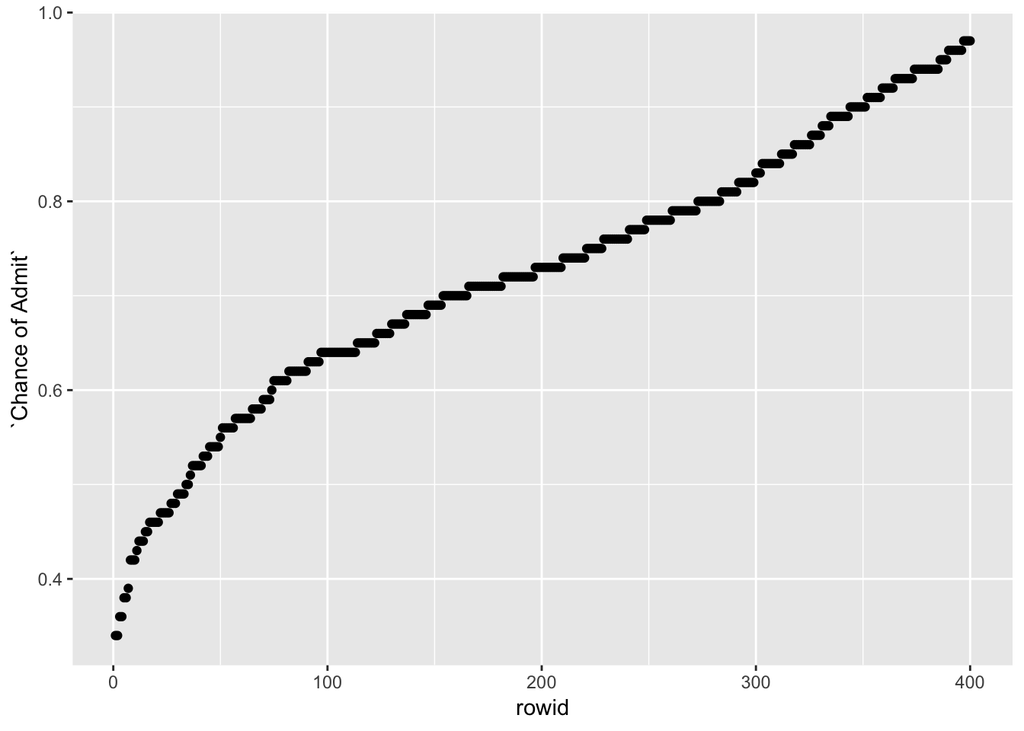

```r
tidy_data %>%
  arrange(`Chance of Admit`) %>%
  rowid_to_column() %>%
  ggplot(aes(x=rowid, y=`Chance of Admit`)) +
  geom_point()
```

Based on the plot, we see a somewhat linear increase in chance, with a curve at the beginning.

To know if the distribution is even, we can look at a box plot.

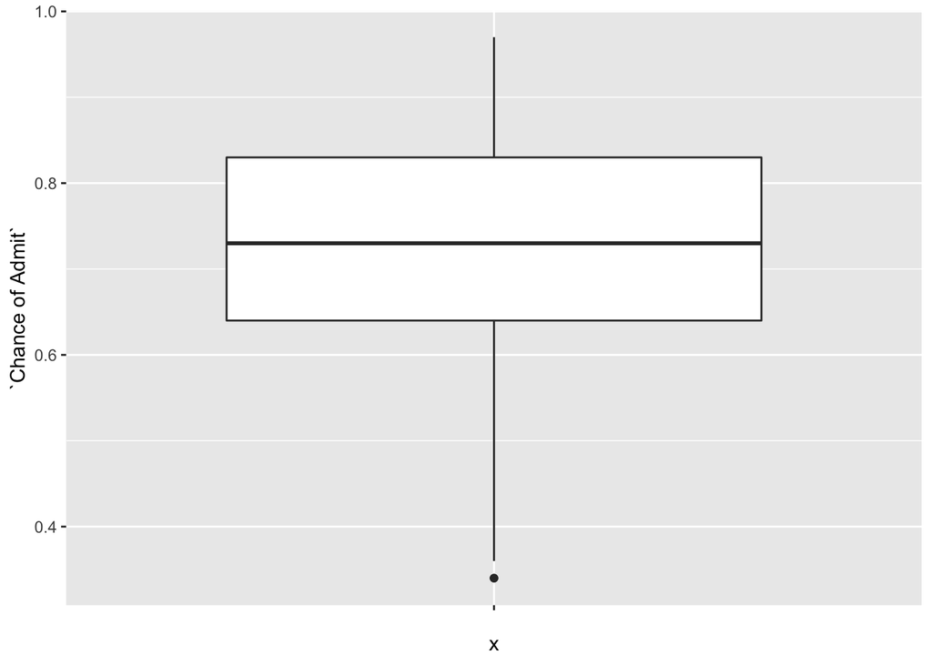

```r
tidy_data %>%
  ggplot(aes(x='', y=`Chance of Admit`)) +
  geom_boxplot()
```

We can also visualize pairs of variables. The GRE is used by thousands of graduate schools around the world, and serves as a standardized test for evaluating all applicants. However, we know that the test score is not the only thing that matters in terms of being accepted, and occasionally, poorer scoring students will still get into a school. To look at continuous variables GRE Score and Chance of Admit, we can produce a scatter plot.

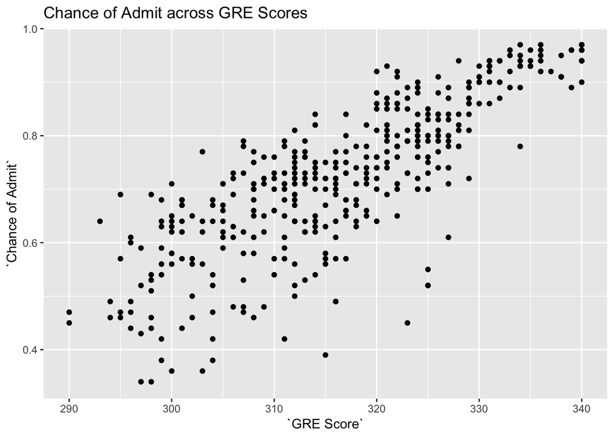

```r
tidy_data %>%
  ggplot(aes(x=`GRE Score`, y=`Chance of Admit`)) +
  geom_point() +
  ggtitle("Chance of Admit across GRE Scores")
```

From the scatter plot, we can see a pattern of Chance of Admit increasing with GRE Score. With a model, we will be better able to quantify the potential relationship.

## 5.2 Summary Statistics

The summary statistics groups the data by GRE scores and then calculates the mean of admit. So the GRE_Scores_Interval groups the GRE Scores in groups of 5 from 290-340. Then, it calculates the mean of the chance of admit for each interval. As you can tell, the GRE Scores increase, the mean chance of admit increases as well. As you can tell the Mean chance of Admit range increases from .52 to .94 as the intervals increase.

```r
summary <- tidy_data %>%
           mutate("GRE_Scores_Interval" = cut(`GRE Score` ,breaks = 10)) %>%
           group_by(GRE_Scores_Interval) %>%
           summarize("Mean Chance of Admit"=mean(`Chance of Admit`))

summary
```

```
## # A tibble: 10 x 2
##    GRE_Scores_Interval `Mean Chance of Admit`
##    <fct>                                <dbl>
##  1 (290,295]                            0.522
##  2 (295,300]                            0.538
##  3 (300,305]                            0.594
##  4 (305,310]                            0.651
##  5 (310,315]                            0.675
##  6 (315,320]                            0.715
##  7 (320,325]                            0.785
##  8 (325,330]                            0.828
##  9 (330,335]                            0.921
## 10 (335,340]                            0.940
```

## 5.3 Data Transformations

Our data transformation consists of centering the data for the previous summary statistics that we performed on GRE vs Mean Chance of Admit. We will then break up the data by the standard deviation instead of by intervals of 5. As you can tell the standard deviations are from -3 to 3 since this was the range of the SD of the data. This then allows us to see the change in the average of the data as the standard deivation away from the mean changes.

```r
sd <- tidy_data %>%
  summarize("Standard_Deviation"= sd(`GRE Score`),"Mean"=mean(`GRE Score`))
sd
```

```
## # A tibble: 1 x 2
##   Standard_Deviation  Mean
##                <dbl> <dbl>
## 1               11.5  317.
```

```r
summary <- tidy_data %>%
           mutate(z = (`GRE Score` - sd$Mean) / sd$Standard_Deviation)
summary
```

```
## # A tibble: 400 x 9
##    `GRE Score` `TOEFL Score` `University Rat…   SOP   LOR  CGPA Research
##          <dbl>         <dbl>            <dbl> <dbl> <dbl> <dbl> <lgl>
##  1         337           118                4   4.5   4.5  9.65 TRUE
##  2         324           107                4   4     4.5  8.87 TRUE
##  3         316           104                3   3     3.5  8    TRUE
##  4         322           110                3   3.5   2.5  8.67 TRUE
##  5         314           103                2   2     3    8.21 FALSE
##  6         330           115                5   4.5   3    9.34 TRUE
##  7         321           109                3   3     4    8.2  TRUE
##  8         308           101                2   3     4    7.9  FALSE
##  9         302           102                1   2     1.5  8    FALSE
## 10         323           108                3   3.5   3    8.6  FALSE
## # … with 390 more rows, and 2 more variables: `Chance of Admit` <dbl>,
## #   z <dbl>
```

```r
summary %>%
           mutate("GRE Centered Score" = cut(z , seq(from= -3, to= 3, by= 1.0))) %>%
           group_by(`GRE Centered Score`) %>%
           summarise("Mean" = mean(`Chance of Admit`))
```

```
## # A tibble: 6 x 2
##   `GRE Centered Score`  Mean
##   <fct>                <dbl>
## 1 (-3,-2]              0.52
## 2 (-2,-1]              0.563
## 3 (-1,0]               0.666
## 4 (0,1]                0.774
## 5 (1,2]                0.911
## 6 (2,3]                0.948
```

# 6 Hypothesis Testing

```r
library(tidyverse)
hypo <- tidy_data %>% lm(formula=`University Rating`~`Chance of Admit`)
broom::tidy(hypo)
```

```
## # A tibble: 2 x 5
##   term              estimate std.error statistic  p.value
##   <chr>                <dbl>     <dbl>     <dbl>    <dbl>
## 1 (Intercept)          -1.04     0.209     -5.01 8.35e- 7
## 2 `Chance of Admit`     5.70     0.283     20.2  6.64e-63
```

# 7 Machine Learning

As students, we want to see what can maximize our chances of getting into a Graduate Program. Given that there are multiple factors in the dataset that may improve chances, we can conduct a linear regression to see if there is a relationship between any of the attributes.

## 7.1 Simple Regression

To look at the relationship between two continuous variables, we can assume that in our population, the relationship between them is given by the linear function $Y = \beta{_0} + \beta{_1}X \\$

Since we are interested in how chance of being admitted is affected by factors (ex: GRE score), we can do the following regression: $Chance of Admit \approx \beta{_0} + \beta{_1}\times GRE Score \\$

In the above graphs used in EDA Visualization, we used components for adding geom_points and geom_boxplots. However, multiple components can be added to a single plot. For example, a geom_smooth component can be layered, Additional information can be found at https://ggplot2.tidyverse.org/reference/gg-add.html

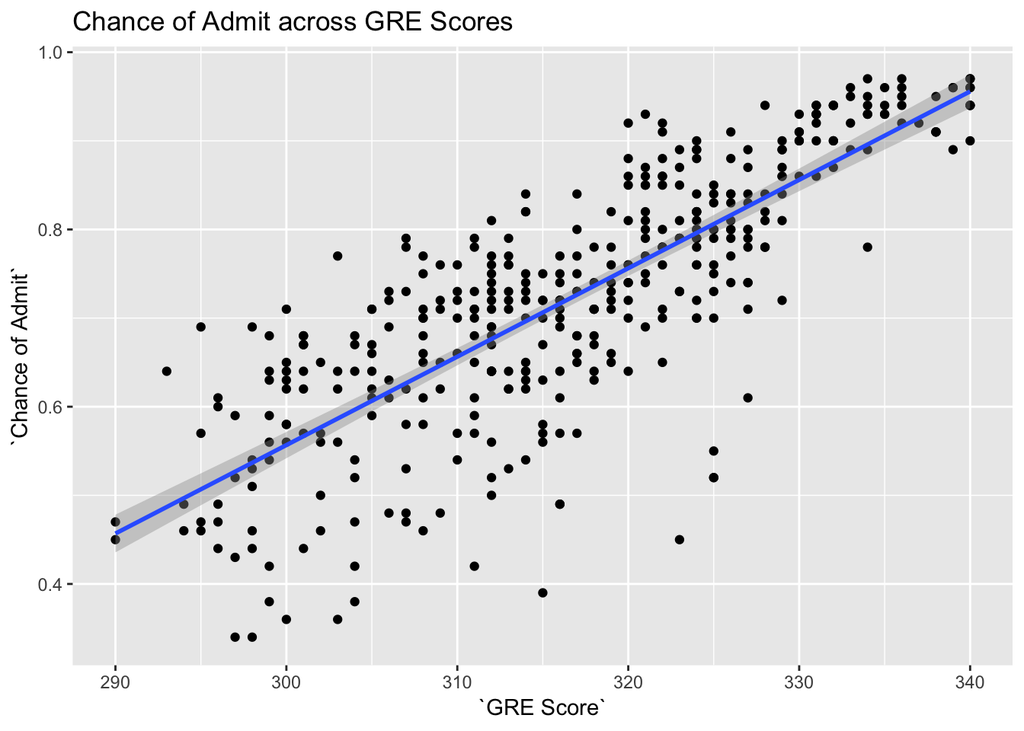

```r
simple_reg <- tidy_data %>%
  ggplot(aes(x=`GRE Score`, y= `Chance of Admit`)) +
  geom_point() +
  geom_smooth(method=lm) +
  ggtitle("Chance of Admit across GRE Scores")
simple_reg
```

```r
# The linear model equation
gre_fit <- lm(`Chance of Admit`~`GRE Score`, data=tidy_data)
gre_fit
```

```
##
## Call:
## lm(formula = `Chance of Admit` ~ `GRE Score`, data = tidy_data)
##
## Coefficients:
## (Intercept)  `GRE Score`
##   -2.436084     0.009976
```

According to the lm function, $\hat\beta{_0} = -2.436084\\$ and $\hat\beta{_1} = 0.009976\\$ This means that on average, an applicant’s chance of admittance would increase by 0.01 for every additional point scored on the GRE.

Now that we have a linear model, we must interpret how well it fits the data. First, we need to check that there is a relationship between Chance of Admit and GRE Score. This can be done with a hypothesis test. $\ H{_0}; \beta{_1} = 0\\$ meaning there is no relationship $\ H{_0}; \beta{_1} \neq 0\\$

```r
gre_fit %>%
  tidy()
```

```
## # A tibble: 2 x 5
##   term        estimate std.error statistic  p.value
##   <chr>          <dbl>     <dbl>     <dbl>    <dbl>
## 1 (Intercept) -2.44     0.118        -20.7 4.88e-65
## 2 `GRE Score`  0.00998  0.000372      26.8 2.46e-91
```

We find that our p value for $\hat\beta{_1}\\$ is much lower than .05, our cutoff for significance. Thus we can state that there is a statistically significant relationship between GRE Score and Chance of Admittance.

## 7.2 Interaction

We know that GRE is a factor for admittance, but what if there are more? In particular, what if a combination of multiple factors gives us a better model for the data? Interaction models allow us to see if the effect of one predictor on the outcome is increased by another predictor.

Graduate schools provide students with more advanced learning in a specialized field. Much of this comes from doing hands on research in their respective programs. While it is not mandatory to conduct research during undergraduate studies, there is a notion that doing so will greatly help your chances of getting into a good school.

Therefore, another variable we can consider is whether an applicant has done research or not. This would require models of conditional expectation, stiill represented as a linear function. $Chance of Admit \approx \beta{_0} + \beta{_1}\times GRE Score + \beta{_2}\times Research + \beta{_3}\times (GRE Score \times Research)\\$

Like in simple regression, we can build our model using geom_smooth

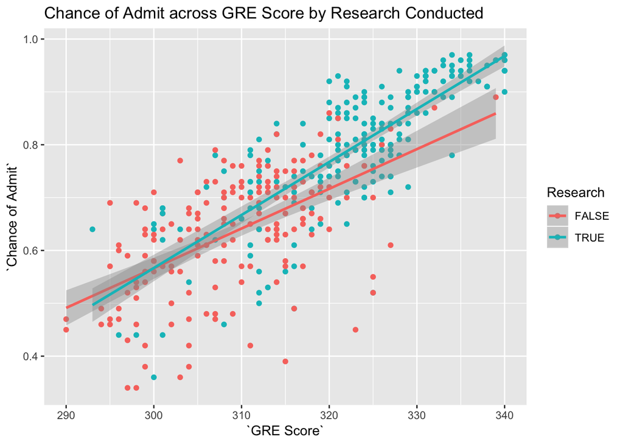

```r
tidy_data %>%
  ggplot(aes(x=`GRE Score`, y=`Chance of Admit`, color=Research)) +
    geom_point() +
    geom_smooth(method=lm) +
    ggtitle("Chance of Admit across GRE Score by Research Conducted")
```

The two lines are similar, but the slope of Research==TRUE appears to be greater.

Now that we have the model, we can see how it fits.

```r
multiple_fit <- lm(`Chance of Admit`~`GRE Score`*Research, data=tidy_data)
multiple_fit_stats <- multiple_fit %>%
  tidy()
multiple_fit_stats %>% knitr::kable()
```

| term | estimate | std.error | statistic | p.value |
| --- | --- | --- | --- | --- |
| (Intercept) | -1.6862380 | 0.2188047 | -7.706589 | 0.0000000 |
| `GRE Score` | 0.0075088 | 0.0007067 | 10.625210 | 0.0000000 |
| ResearchTRUE | -0.7552192 | 0.2868913 | -2.632423 | 0.0088094 |
| `GRE Score`:ResearchTRUE | 0.0025187 | 0.0009107 | 2.765613 | 0.0059475 |

## 7.3 ANOVA

An Analysis of Variance Test allows us to compare models and see which one is a better fit for the data.

```r
anova(gre_fit, multiple_fit)
```

```
## Analysis of Variance Table
##
## Model 1: `Chance of Admit` ~ `GRE Score`
## Model 2: `Chance of Admit` ~ `GRE Score` * Research
##   Res.Df    RSS Df Sum of Sq      F    Pr(>F)
## 1    398 2.8873
## 2    396 2.7410  2   0.14636 10.573 3.363e-05 ***
## ---
## Signif. codes:  0 '***' 0.001 '**' 0.01 '*' 0.05 '.' 0.1 ' ' 1
```

## 7.4 Conclusion

In sum, our analysis is used to show our audience the factors that go into admissions and acceptance into Graduate schools. It is used to open the eyes of the people who want to join these extremely competitve programs and provide general knowledge for all students who aspire to better themselves with education. I think that we will enable and empower students around the United States with this information by providing them with external resources as well as backing up our points with data. I hope that our project makes Graduate programs more accessible through the knowledge we provide.